R입문 (전북대학교 2021년 2학기)

# (1주차) 9월7일

2005년 예비평가(나) 12월/평가원26(고3) 문제풀이

Sep 7, 2021 • 최규빈 • 1 min read

- 강의영상
- R은 좋은 계산기 이다.
  - 2005년 예비평가(나) 12월/평가원26(고3)
- 숙제

### 강의영상

[video not shown]

`-` (1/2): 2005년 예비평가(나) 12월/평가원26(고3) 첫번째 풀이

`-` (2/2): 2005년 예비평가(나) 12월/평가원26(고3) 다양한 풀이 + 과제설명

### R은 좋은 계산기 이다.

#### 2005년 예비평가(나) 12월/평가원26(고3)

어떤 호수에서 수면에서의 빛의 세기가 $I_0$일 때, 수면이 $d$m인 곳에서의 빛의 세기 $I_d$는 다음과 같이 나타내어진다고 한다.

$$I_d=I_0 2^{-0.25d}$$

이 호수에서 빛의 세기가 수면에서의 빛의 세기의 25%인 곳의 수심은? (3점)

(1) 16m

(2) 12m

(3) 10m

(4) 8m

(5) 4m

(풀이1)

```r
I0=1
d=8
Id=I0*0.25
```

```r
I0*2^(-0.25*d) ## 0.25 랑 비슷하면 된다. 현재는 Id=0.25니까..
```

```
[1] 0.25
```

(풀이2)

```r
d=8
y=I0*2^(-0.25*d)/Id
y
```

```
[1] 1
```

`-` $y=1$이 나오는 $d$를 찾아보면된다. $\to$ 찾아보니까 $d=8$

(풀이3)

`-` 함수라는걸 만들어보자.

`-` $d$를 입력하면, 알아서 $y$가 계산되면 좋겠다.

$$y=f(d)$$

```r
f<-function(d){
    y=I0*2^(-0.25*d)/Id
    y
}
```

`-` $y=f(d)=\frac{I_0 2^{-0.25 d}}{I_d}$ 를 함수를 만들자.

`-` $y=1$이 되는 $d$를 찾아보자. 그러면 답이다.

```r
f(8)
```

```
[1] 1
```

`-` $d=8$이 답이다.

(풀이4)

`-` $(d,f(d))$ 혹은 $(d,y)$를 그래프로 그려보자.

```r
d<-c(1,2,3)
```

```r
d<-seq(from=0,to=10,by=0.01)
```

```r
y=I0*2^(-0.25*d)/Id
```

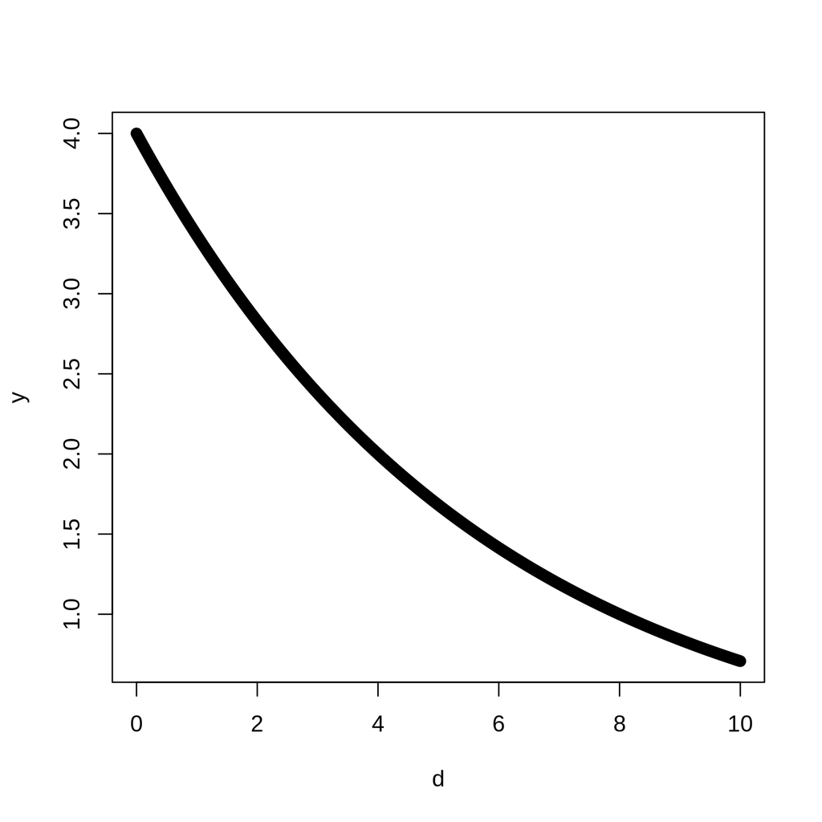

```r
plot(d,y)
```

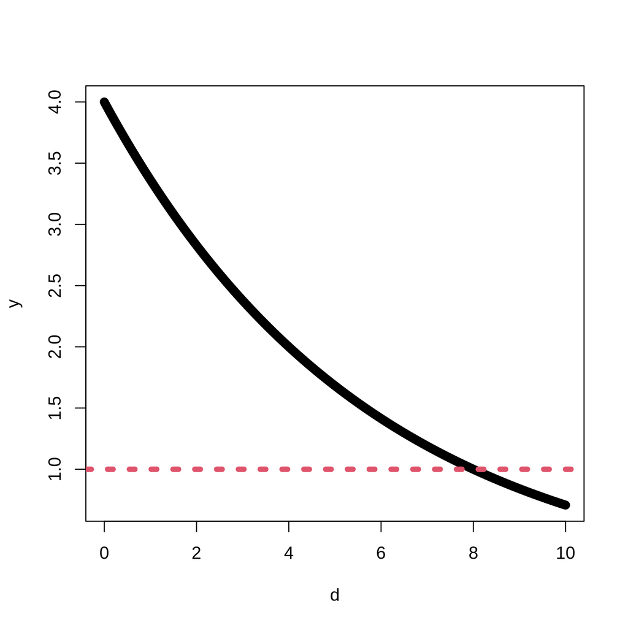

```r
plot(d,y)
abline(h=1,col=2,lwd=5,lty=3)
```

(풀이5)

```r
x_<-c(1,2,3,2,5)
```

```r
x_ == 3
```

```
[1] FALSE FALSE  TRUE FALSE FALSE
```

```r
d[y==1]
```

```
[1] 8
```

### [숙제](https://ieilms.jbnu.ac.kr/)

`-` 아래그림에서 수평선의 위치를 $y=2$로 조정하여 그려볼것

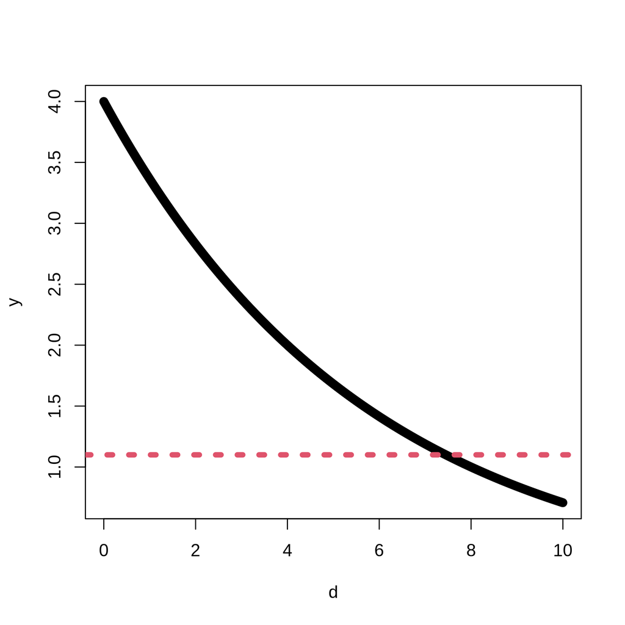

```r
plot(d,y)
abline(h=1.1,col=2,lwd=5,lty=3)
```